# General Social Survey

# 2 Introduction Question 2

Now answer Is belief in the bigbang theory (BIGBANG) independent of belief in the afterlife (POSTLIFE)

## 2.1 Methods

The two variable we’re looking at are the belief of the bigbang theory (BIGBANG) and the afterlife (POSTLIFE), both factor variables. For this project a barchart will be used for the graphical results and a table1 command for the numerical results.

##Results

### 2.1.1 Descriptive Results

The numerical test suggest that 91% of people who believe in postlife but does not believe in the bigbang theory whereas 81% beleive in both postlife and the bigbang theory.

#### 2.1.1.1 Graphical Descriptive Results

The boxchart is a visional aid pointing out that those who believe in the bigbang theory and those who believe in the afterlife and no the bigbang theory are about the same proportion.

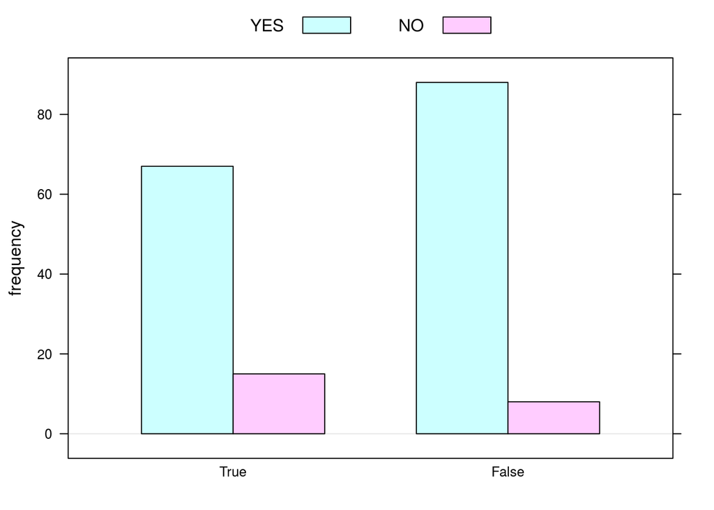

```r
barchartGC(~BIGBANG + POSTLIFE,data=mydata4)
```

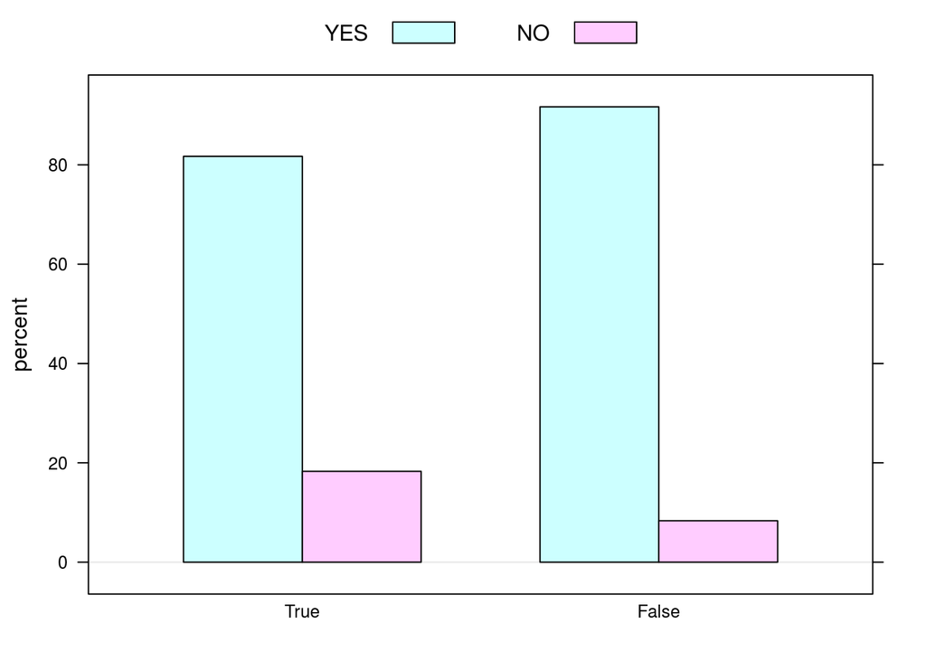

```r
barchartGC(~BIGBANG + POSTLIFE, data=mydata4, type="percent")
```

According to the boxplot, among those who believe in the bigbang theory and the afterlife is about the same as those who don’t believe in the bibbang theory.

#### 2.1.1.2 Numerical Descriptive Results

```r
table1 <- xtabs(~BIGBANG+ POSTLIFE, data=mydata4)
rowPerc(table1)
```

```
##        POSTLIFE
## BIGBANG    YES     NO  Total
##   True   81.71  18.29 100.00
##   False  91.67   8.33 100.00
```

```r
colPerc(table1)
```

```
##        POSTLIFE
## BIGBANG    YES     NO
##   True   43.23  65.22
##   False  56.77  34.78
##   Total 100.00 100.00
```

The numerical descriptive results suggest there is no relationship between belief in both the bigbang theory and the afterlife. There is not enough evidence.

### 2.1.2 Inferential Results

```r
chisq.test(table1)
```

```
##
##  Pearson's Chi-squared test with Yates' continuity correction
##
## data:  table1
## X-squared = 3.0637, df = 1, p-value = 0.08006
```

```r
chisqtestGC(table1)
```

```
## Pearson's Chi-squared test with Yates' continuity correction
##
## Observed Counts:
##        POSTLIFE
## BIGBANG YES NO
##   True   67 15
##   False  88  8
##
## Counts Expected by Null:
##        POSTLIFE
## BIGBANG  YES   NO
##   True  71.4 10.6
##   False 83.6 12.4
##
## Contributions to the chi-square statistic:
##        POSTLIFE
## BIGBANG  YES   NO
##   True  0.27 1.83
##   False 0.23 1.56
##
##
## Chi-Square Statistic = 3.0637
## Degrees of Freedom of the table = 1
## P-Value = 0.0801
```

```r
fisher.test(table1)
```

```
##
##  Fisher's Exact Test for Count Data
##
## data:  table1
## p-value = 0.07143
## alternative hypothesis: true odds ratio is not equal to 1
## 95 percent confidence interval:
##  0.1410591 1.0968350
## sample estimates:
## odds ratio
##  0.4081275
```

$H_O$: There is no relationship between the belief in the bigbang theory (BIGBANG) and the afterlife (POSTLIFE).

$H_1$: There is a relationship between the belief in the bigbang theory and the afterlife.

# 3 Introduction Question 3

Finally determine if a persons opinion on death penalty (CAPPUN) is independent of their race (RACE).

## 3.1 Methods

The two variable we’re looking at are the death penalty (CAPPUN) and race (RACE), both are factor variables. For this project a barchart will be used for the graphical results and a table1 command for the numerical results.

##Results

### 3.1.1 Descriptive Results

The boxplot shows that the white race and other race are typically more in favor of capital punishment than the black race.

#### 3.1.1.1 Graphical Descriptive Results

The boxplot shows that the black race are more likely to oppose the capital punishment than the white race and the other races in this study.

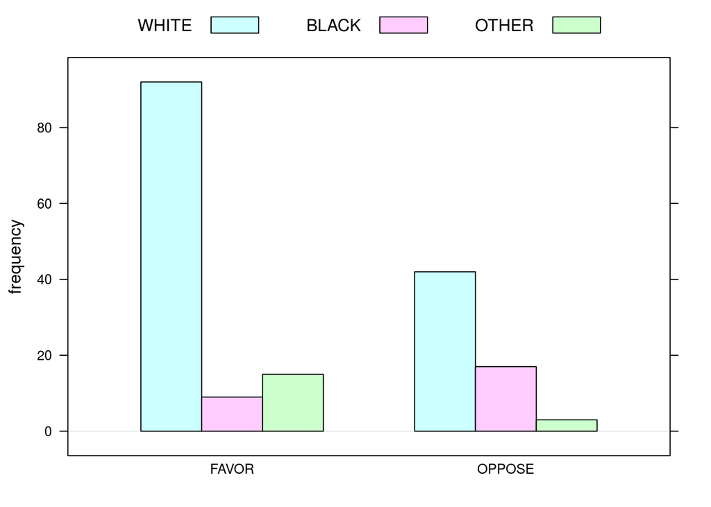

```r
barchartGC(~CAPPUN + RACE,data=mydata4)
```

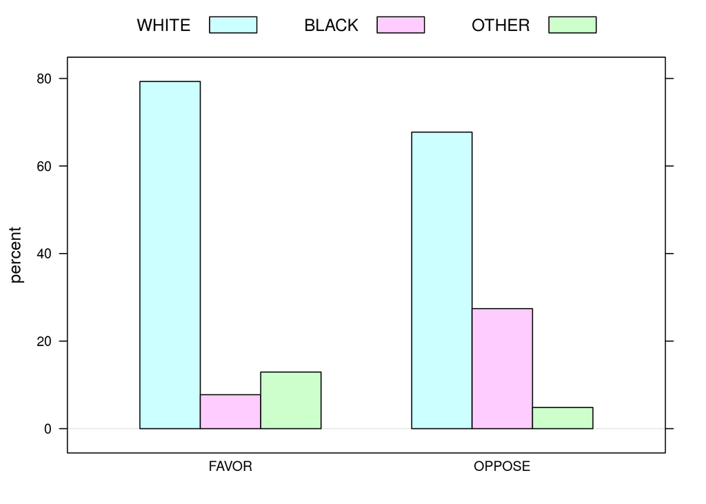

```r
barchartGC(~CAPPUN + RACE, data=mydata4, type="percent")
```

#### 3.1.1.2 Numerical Descriptive Results

```r
table1 <- xtabs(~CAPPUN+ RACE, data=mydata4)
rowPerc(table1)
```

```
##         RACE
## CAPPUN    WHITE  BLACK  OTHER  Total
##   FAVOR   79.31   7.76  12.93 100.00
##   OPPOSE  67.74  27.42   4.84 100.00
```

```r
colPerc(table1)
```

```
##         RACE
## CAPPUN    WHITE  BLACK  OTHER
##   FAVOR   68.66  34.62  83.33
##   OPPOSE  31.34  65.38  16.67
##   Total  100.00 100.00 100.00
```

### 3.1.2 Inferential Results

```r
chisq.test(table1)
```

```
##
##  Pearson's Chi-squared test
##
## data:  table1
## X-squared = 14.027, df = 2, p-value = 0.0008996
```

```r
chisqtestGC(table1)
```

```
## Pearson's Chi-squared test
##
## Observed Counts:
##         RACE
## CAPPUN   WHITE BLACK OTHER
##   FAVOR     92     9    15
##   OPPOSE    42    17     3
##
## Counts Expected by Null:
##         RACE
## CAPPUN   WHITE BLACK OTHER
##   FAVOR  87.33 16.94 11.73
##   OPPOSE 46.67  9.06  6.27
##
## Contributions to the chi-square statistic:
##         RACE
## CAPPUN   WHITE BLACK OTHER
##   FAVOR   0.25  3.72  0.91
##   OPPOSE  0.47  6.97  1.71
##
##
## Chi-Square Statistic = 14.0272
## Degrees of Freedom of the table = 2
## P-Value = 9e-04
```

$H_O$: There is no relationship between the death penalty (CAPPUN) and race (RACE).

$H_1$: There is a relationship between the death penalty (CAPPUN) and race (RACE).

# 4 Discussion and Conclusion

Question 2) The boxplot provided a graphical image that suggested that the proportion amount of those who believe in the bigbang theory are about the same as those who believe in the afterlife but doesn’t believe in the bigbang theory. Whereas the numerical test suggest that 91% of people who believe in postlife but does not believe in the bigbang theory whereas 81% beleive in both postlife and the bigbang theory.The numerical descriptive results suggest there is no relationship between belief in both the bigbang theory and the afterlife. There is not enough evidence. However given the null hypothesis is true 8 percent of the time, we fail to reject the null hypothesis.